# Predicting League Of Legends

Michael Makogon

May 18, 2018

# Introduction

In the past 6 years, I’ve poured thousands of hours into playing League of Legends, an online video game which pits two teams of 5 against each other in a race to the other team’s base. The game is very complex, with a large selection of unique items, runes, and characters (also known as champions) that allow every game to be completely unique. Much of your time in the game is dedicated to ranking up, and many players are only focused on climbing the competitive ladder. League is popular worldwide, and has the biggest professional e-sports scene of all time.

Throughout the time that the game has existed, Riot Games, the company behind the game, has been constantly patching and changing the game to make it as balanced as possible. The goal is to make every champion be balanced, or have an equal chance of winning the game. A champion’s winrate, or the percentage of games they win, should be as close as possible to 50%. A champion even 5% above or below that mark is considered unbalanced, and going 10% above or below that mark is considered extremely unfair. League of Legends is a game of inches, and even slight deviations in winrate have a great importance to players, and an even greater one to professionals with careers on the line.

The question I want to ask was how: well can I predict the winner of a game? This tutorial walks you through the entire pipeline I used in answering that question. I found a [great data set](https://www.kaggle.com/paololol/league-of-legends-ranked-matches/data) on kaggle.com which had over 180,000 ranked matches recorded, each with 10 players. The data set included data from the beginning of the game as well as the end of the game. By the end of the game, the winning team will definitely be the one that did better, and the stats will easily reflect that. However, predicting the winner of a game *after* that game has ended isn’t really useful. This tutorial will focus on my efforts at analyzing data that can be learned at the start of the match, rather than the end of the match.

# Setup

```r
knitr::opts_chunk$set(echo = TRUE)

library(tidyverse)
library(stringr)
library(knitr)
library(kableExtra)
library(ggplot2)
library(ISLR)
library(cvTools)
library(tree)
```

I first need to include the libraries that have functions I need to use

- **tidyverse** gives some necessary data tidying functions
- **stringr** gives string manipulation
- **knitr** and **kableExtra** allow me to present data tables easily
- **ggplot2** is a graphing library
- **ISLR**, **cvTools**, **tree**, and **randomForest** all help with predictive models and cross validation

```r
# Create a vector representing graph labelss for versions so that not they don't get crowded
ver_labels <- c("4.7", "", "", "", "4.11", "", "", "", "4.15", "", "", "", "4.19", "", "",
                "5.1", "", "", "", "5.5", "", "", "", "5.9", "", "", "",
                "5.13", "", "", "", "5.17", "", "", "", "5.21", "", "", "",
                "6.1", "", "", "", "6.5", "", "", "", "6.9", "", "", "",
                "6.13", "", "", "", "6.17", "", "", "", "6.21", "", "", "",
                "7.1", "", "", "", "7.5", "", "", "", "", "7.10", "")

# Put all kables in html format
options(knitr.table.format = "html")

# Create a function to quickly create a kable with specific styling
get_kable <- function(df) {
  df %>%
    sample_n(5) %>%
    kable() %>%
    kable_styling(bootstrap_options = c("striped", "hover", "condensed", "responsive"))
}

# Create a function to simulate finding the mode of any attribute
Mode <- function(x) {
  ux <- unique(x)
  ux[which.max(tabulate(match(x, ux)))]
}
```

I also needed to create a few functions that I’ll use down the line

- I need to label version graphs without the x axis getting to cramped
- I need a function to easily create a table with my preferred settings
- I need a function to find the mode of a variable

```r
# Read in champion id data
champs <- read_csv("champs.csv") %>%
  drop_na() %>%
  select(champion = name, championid = id)

# Read in match data
matches <- read_csv("matches.csv") %>%
  drop_na() %>%
  select(matchid = id, seasonid, duration, version)

# Read in stats data in each data frame
stats1 <- read_csv("stats1.csv")

stats2 <- read_csv("stats2.csv")


# Add the two data frames together
stats <- rbind(stats1, stats2) %>%
  drop_na()

# Read in match participants data
participants <- read_csv("participants.csv") %>%
  drop_na()

# Read in match bans data
teambans <- read_csv("teambans.csv") %>%
  drop_na()

# Read in team stats data
teamstats <- read_csv("teamstats.csv") %>%
  drop_na()
```

I downloaded the data directly from the Kaggle repository and loaded it into the environment, dropping any NA values.

# Data Wrangling

```r
# Extrapolate exact position data from role
participants$position[participants$role == "DUO_SUPPORT"] <- "SUPPORT"
participants$position[participants$role == "DUO_CARRY"] <- "CARRY"
participants <- participants %>%
  # Filter out bot lane champs that didn't get assigned the right position
  filter(position != "BOT") %>%
  # Don't need the role since position was extrapolated
  select(-role) %>%
  # Classify participants into teams based off of player number
  mutate(team = ifelse(player <= 5, "BLUE", "RED"))

matches <- matches %>%
  # Get a more generalized version number using regex, ignore tiny patches
  extract(version, c("ver_major", "ver_minor"), "^([:digit:]+).([:digit:]+)") %>%
  type_convert(cols(ver_major = col_integer(),
                    ver_minor = col_integer())) %>%
  mutate(ver = (ver_major * 100) + ver_minor) %>%
  # Ignore remakes (games less than 4 minutes, with 60 seconds of buffer in case)
  filter(duration > 300)

# Add the most common role to the participants data frame
participants <- participants %>%
  left_join(champs, by = "championid") %>%
  right_join(matches, by = "matchid")

# Create a new data frame with each champion's most common role in the most recent season
champ_roles <- participants %>%
  group_by(champion) %>%
  summarize(common_role = Mode(position))

# Add primary champ roles to participants
participants <- participants %>%
  left_join(champ_roles, by = "champion")

# Refactor win from integer (1/0) to boolean (T/F)
stats <- stats %>%
  mutate(win = (win == 1))

teambans <- teambans %>%
  # Join the champion id's with names
  left_join(champs, by = "championid") %>%
  # Add primary champ roles
  left_join(champ_roles, by="champion")

teamstats <- teamstats %>%
  # Refactor teamid into team name
  mutate(team = ifelse(teamid == 100, "BLUE", "RED"))
```

I’m unsure exactly how the data was collected, but I need to manipulate parts of it that weren’t collected properly. `position` and `role` are two seperate incomplete attributes that I combined. Players 1-5 are the `BLUE` team and 6-10 are the `RED` team. `version` is in a form I couldn’t graph well, so I need to extract the major and minor version numbers from it: `ver_major` and `ver_minor`, then combine them into a graphable version number. League of Legends has a “remake” feature, allowing teams to end the game early if a player never connect in 4 minutes. I don’t want to these games so I filter based on game `duration`. I need to give each `championid` it’s corresponding name. For easier classification in the future, I will find the most common position for each champion and store that in `common_role`.

# Just for fun

With the data sets ready to use, I wanted to get an initial visualization of some of the data, so I tried finding a few different data points I was interested in.

## Game Duration

League games are definitely a timesink and can last anywhere from 15 to 60 minutes. Over the past couple seasons, some of the changes to the game have been aimed towards reducing the game time. I averaged the game times for each version and graphed it below. Games have definitely been getting shorter recently, but not by a ton.

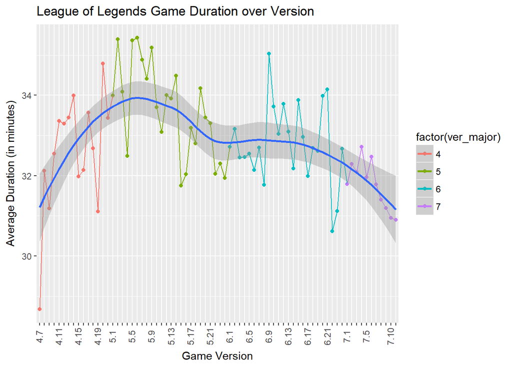

```r
participants %>%
  group_by(ver_major, ver) %>%
  # Get the average duration for each version in seconds converted to minutes
  mutate(minutes = (duration / 60)) %>%
  summarize(avg_duration = mean(minutes)) %>%
  # Graph the resulting data with a line of best fit
  ggplot(aes(x = factor(ver),
             y = avg_duration,
             group = 1,
             color=factor(ver_major))) +
    geom_point() +
    geom_line() +
    geom_smooth(method = "loess") +
    theme(axis.text.x = element_text(angle = 90,
                                     vjust = 0.4,
                                     size = 9)) +
    labs(x="Game Version",
         y="Average Duration (in minutes)",
         title="League of Legends Game Duration over Version") +
    scale_x_discrete(labels=ver_labels)
```

## Flash Key

One of the components of League of Legends is summoner spells, powerful abilities that anyone can take. Each player gets two spells, by default on the D and F keys. The most popular one by far is “Flash”, an instant short-range teleport that is considered necessary for almost every character. A very popular joke-debate is which key should flash be on. Nobody is really serious about their opinion but I was interested if there is an actual difference. First I wanted to see which key is more popular, which is graphed below. It looks like it’s fairly consistent, but overall Flash on D takes the cake.

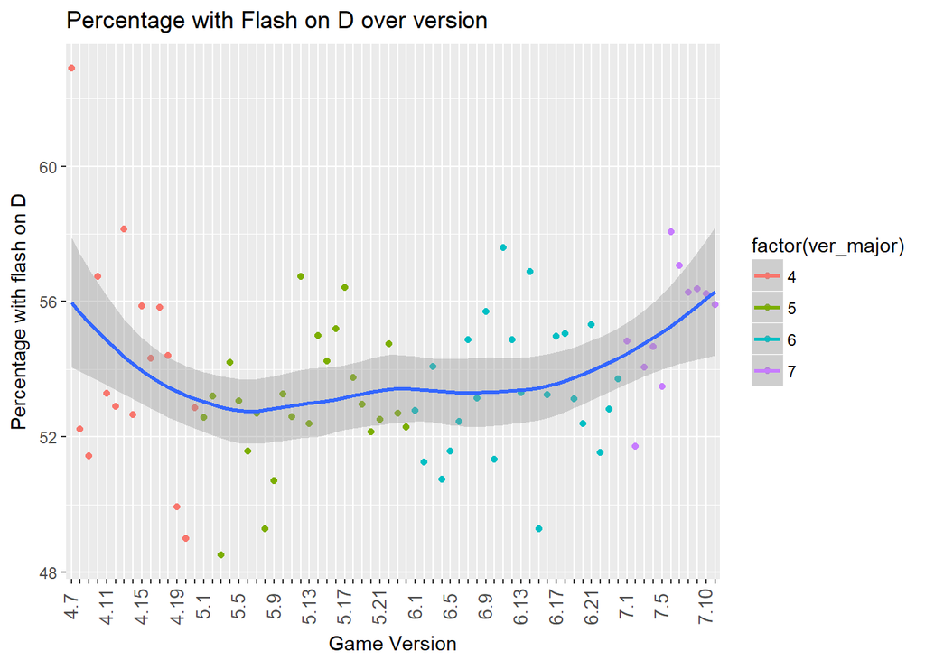

```r
participants %>%
  group_by(ver_major, ver) %>%
  # Only consider participants that actually take flash
  filter(ss1 == 4 | ss2 == 4) %>%
  # Get bool, TRUE if flash is on the D key
  mutate(flash = (ss1 == 4)) %>%
  # Get percentage with flash on D for each version
  summarize(avg_flash = 100 * mean(flash)) %>%
  # Graph the resulting data with a line of best fit
  ggplot(aes(y = avg_flash,
             x = factor(ver),
             group = 1,
             color = factor(ver_major))) +
    geom_point() +
    geom_smooth(method = "loess") +
    theme(axis.text.x = element_text(angle = 90,
                                     vjust = 0.4,
                                     size = 10)) +
    labs(x="Game Version",
         y="Percentage with flash on D",
         title="Percentage with Flash on D over version") +
    scale_x_discrete(labels=ver_labels)
```

## Flash Key Winrate

Next the question is which key actually wins more? I was hoping for the F key because it’s what I use. The results are in and the D key takes the slight advantage. However, both winrates are above 50%, which means there’s probably some minor errors in the data. That must be why the F key, the *clearly superior option*, didn’t win (just kidding, it doesn’t really matter).

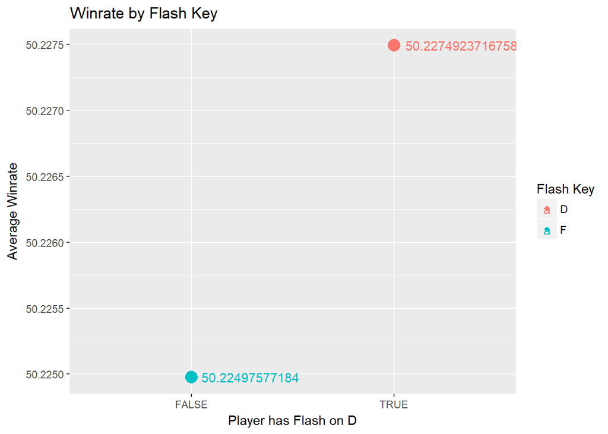

```r
stats %>%
  # join with participant data
  right_join(participants, by = "id") %>%
  select(win, ss1, ss2) %>%
  # Only consider participants that actually take flash
  filter(ss1 == 4 | ss2 == 4) %>%
  # Get bool, TRUE if flash is on the D key
  mutate(flash = (ss1 == 4)) %>%
  # Get average winrate for each flash key
  group_by(flash) %>%
  summarize(winrate = 100 * mean(win, na.rm = TRUE)) %>%
  # Graph the resulting data for each flash key
  ggplot(aes(y = winrate,
             x = flash,
             color = c("F", "D"))) +
    geom_point(aes(size = 2)) +
    geom_text(aes(label = winrate,
                  hjust = -0.1)) +
    labs(x="Player has Flash on D",
         y="Average Winrate",
         title="Winrate by Flash Key",
         color = "Flash Key") +
    guides(size=FALSE)
```

## Winrate Over KDA

I’m also interested in improving my own play. One of the things I think I need to improve on is reducing how much I die. I graphed the winrate over the kill to death ratio to see how much it really matters. It looks like I should really be playing safer.

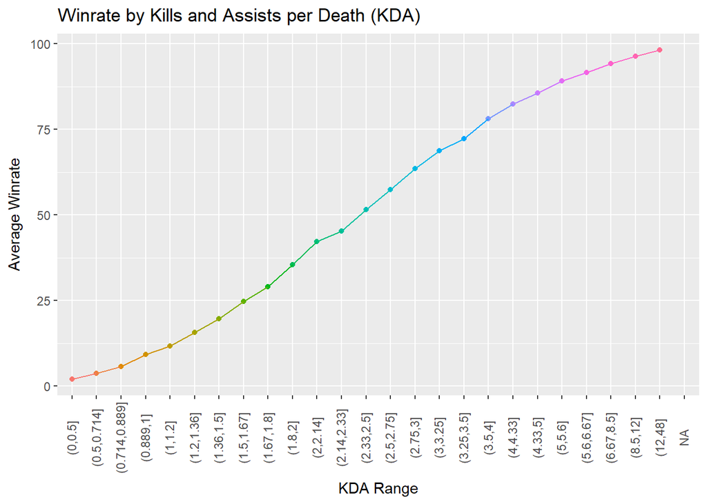

```r
# Create a new data frame to calculate kda
kda_stats <- stats

# Treat entities with 0 deaths as 1 for the purpose of KDA calculations
kda_stats$deaths[kda_stats$deaths == 0] <- 1

kda_stats %>%
  # Calculate kda for each entity
  mutate(kda = (kills + assists)/deaths) %>%
  # Join with other stats to remove incalculable values
  right_join(select(participants, id), by = "id") %>%
  # Divide kda range into 25 buckets, scaled to each have the same size, plus one bucket for NA
  mutate(kda_range = cut(kda, breaks=quantile(kda, probs=seq(0,1,len=26), na.rm=TRUE))) %>%
  # Get winrate for each KDA range
  group_by(kda_range) %>%
  summarize(winrate = 100 * mean(win)) %>%
  # Graph the resulting data for each KDA, with a line in between
  ggplot(aes(y = winrate,
             x = kda_range,
             color = kda_range,
             group = 1)) +
    geom_point(na.rm=TRUE) +
    geom_line(na.rm=TRUE) +
    labs(x="KDA Range",
         y="Average Winrate",
         title="Winrate by Kills and Assists per Death (KDA)") +
    guides(color=FALSE) +
    theme(axis.text.x = element_text(angle = 90,
                                     vjust = 0.4))
```

# Creating predictor variables

At the beginning of the game we only know what champions are picked/banned. In order to determine who will win from that, I’m going to need to determine some data about each team and whether that affects their chances of winning.

## CS/Min

The first variable I’m interested in is the champions CS per minute. CS is Creep Score and is the number of little minions you kill during a game. Killing the minions grants gold, and CS is one of the best ways to increase your gold income in a game

### Calculate CS/Min for each person in each game

First I calculated the CS/Min rate for each person per game. However, only 3 out of the 5 roles actually are focused on killing minions. The first three go down each lane and kill the minions, the fourth supports the champion in the bottom lane, and the fifth roams around the map. I only need to consider the three important positions.

```r
cs_df <- stats %>%
  # Join with participant data to get position
  right_join(participants, by = "id") %>%
  # Only include positions that kill the CS in a lane
  filter(position == "CARRY" | position == "MID" | position == "TOP") %>%
  # Divide CS  by duration to get CS/min rate
  # CS = creep score = minions killed
  mutate(cs_min = totminionskilled/(duration/60)) %>%
  na.omit() %>%
  select(matchid, team, champion, cs_min, win)

get_kable(cs_df)
```

| matchid | team | champion | cs_min | win |
| --- | --- | --- | --- | --- |
| 21973 | RED | Tryndamere | 6.297454 | FALSE |
| 42435 | RED | Draven | 5.585814 | FALSE |
| 86665 | BLUE | Ashe | 8.670213 | TRUE |
| 21927 | BLUE | Fizz | 5.137931 | FALSE |
| 117040 | RED | Katarina | 5.570370 | TRUE |

### Test correlation between CS/Min and winrate

I’ll graph the winrate based on each champion’s CS/Min rate. There is defintely a correlation between CS/Min and winrate.

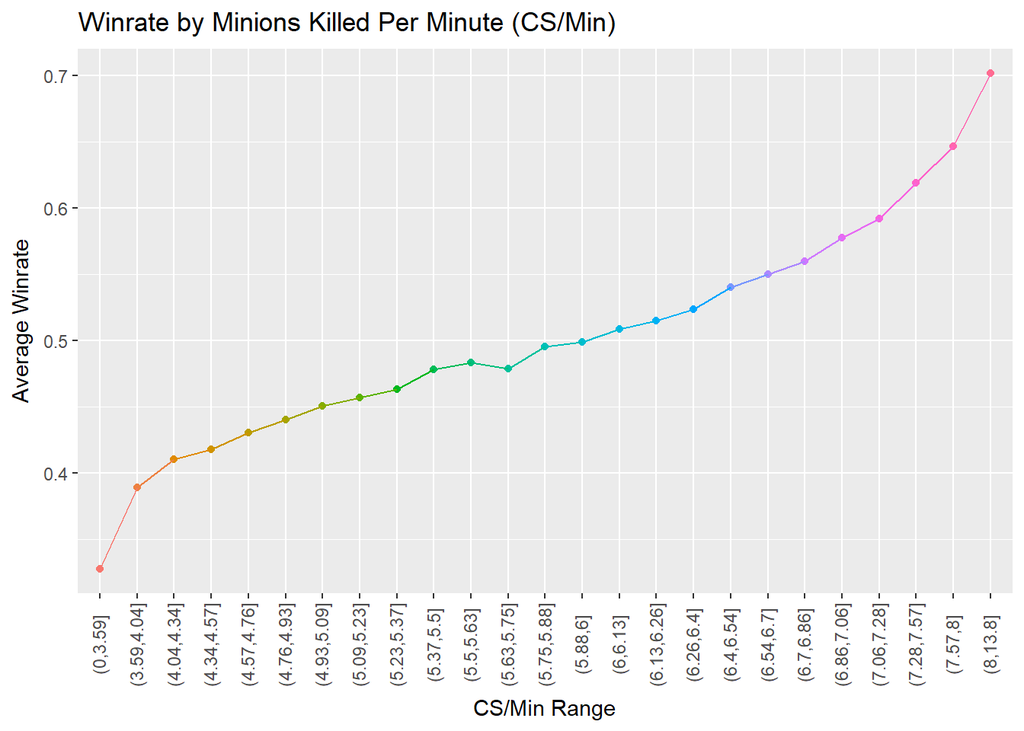

```r
cs_df %>%
  # Divide kda range into 25 buckets, scaled to each have the same size, plus one bucket for NA
  mutate(cs_range = cut(cs_min, breaks=quantile(cs_min, probs=seq(0,1,len=26), na.rm=TRUE))) %>%
  # Get winrate for each CS range
  group_by(cs_range) %>%
  summarize(winrate = mean(win)) %>%
  drop_na() %>%
  # Graph the resulting data for each CS, with a line in between
  ggplot(aes(y = winrate,
             x = cs_range,
             color = cs_range,
             group = 1)) +
    geom_point(na.rm = TRUE) +
    geom_line(na.rm=TRUE) +
    labs(x="CS/Min Range",
         y="Average Winrate",
         title="Winrate by Minions Killed Per Minute (CS/Min)") +
    guides(color=FALSE) +
    theme(axis.text.x = element_text(angle = 90,
                                     vjust = 0.4))
```

### Calculate team average CS/Min for each game

In order to find how this affects the game, I determined each champion’s average CS/Min rate. I then need to average out the CS/Min rate for each team and find the difference between them and their enemy.

```r
team_cs_df <- cs_df %>%
  na.omit() %>%
  # Get average CS/Min for each champion
  group_by(champion) %>%
  mutate(avg_cs = mean(cs_min)) %>%
  # Get average CS/Min for each team and whether they won
  group_by(matchid, team, win) %>%
  summarize(team_cs = mean(avg_cs)) %>%
  # Get the average CS/Min of each team's opponent
  group_by(matchid) %>%
  mutate(cs_lag = lag(team_cs),
         cs_lead = lead(team_cs))

# Combine the CS/Min opponent columsn into one column
team_cs_df$enemy_cs <- team_cs_df$cs_lag
team_cs_df$enemy_cs[!is.na(team_cs_df$cs_lead)] = team_cs_df$cs_lead[!is.na(team_cs_df$cs_lead)]

team_cs_df <- team_cs_df %>%
  select(-cs_lag, -cs_lead) %>%
  ungroup() %>%
  # Calculate the CS/Min difference between each team and their opponent
  mutate(cs_diff = team_cs - enemy_cs)

get_kable(team_cs_df)
```

| matchid | team | win | team_cs | enemy_cs | cs_diff |
| --- | --- | --- | --- | --- | --- |
| 131077 | RED | TRUE | 6.009952 | 5.909365 | 0.1005874 |
| 44512 | BLUE | FALSE | 5.938564 | 5.858106 | 0.0804586 |
| 120761 | BLUE | FALSE | 5.733314 | 5.747241 | -0.0139265 |
| 71767 | BLUE | TRUE | 5.512267 | 5.972333 | -0.4600657 |
| 88098 | BLUE | TRUE | 5.647245 | 6.114280 | -0.4670348 |

### Test correlation between team CS/Min differences and winrate

Now I need to test if this stat is useful and has any correlation at all. I’ll graph team winrate based off of this difference. There is definitely correlation, so I will most likely be using this stat in my final model.

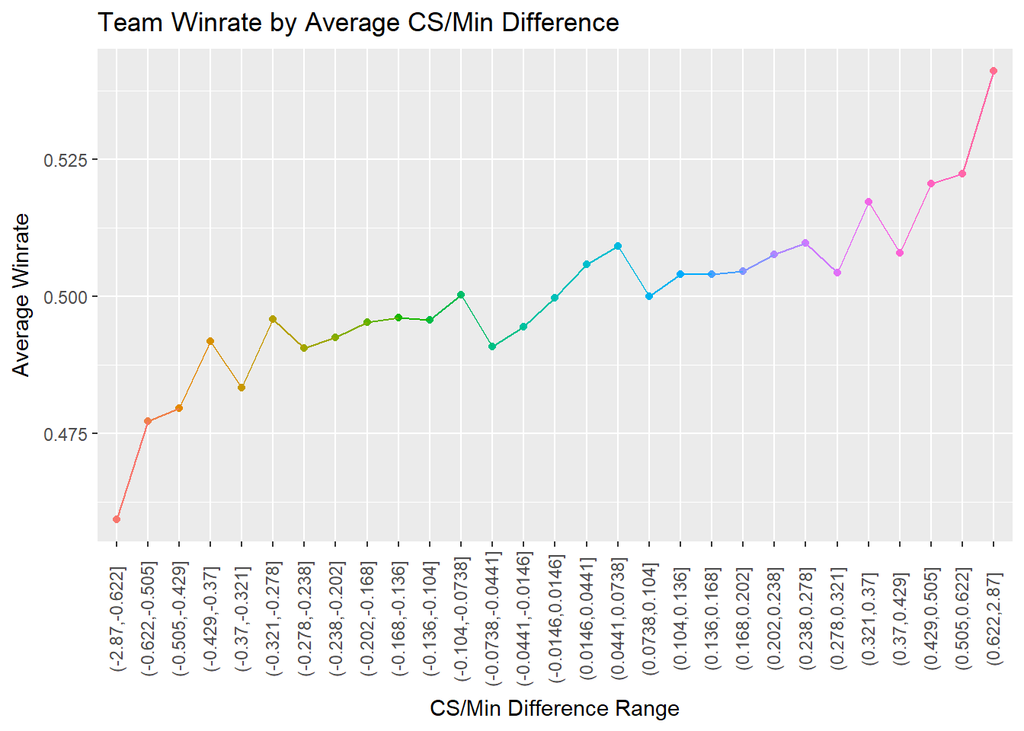

```r
team_cs_df %>%
  na.omit() %>%
  # Divide CS/Min difference range into 30 buckets, scaled to each have the same size
  mutate(cs_range = cut(cs_diff, breaks=quantile(cs_diff, probs=seq(0,1,len=30)))) %>%
  # Get the average winrate for each CS/Min difference range
  group_by(cs_range) %>%
  summarize(winrate = mean(win)) %>%
  na.omit() %>%
  # Graph the winrates of each range
  ggplot(aes(y = winrate,
             x = cs_range,
             color = cs_range,
             group = 1)) +
    geom_point() +
    geom_line() +
    guides(color=FALSE) +
    theme(axis.text.x = element_text(angle = 90,
                                     vjust = 0.4)) +
    labs(x="CS/Min Difference Range",
         y="Average Winrate",
         title="Team Winrate by Average CS/Min Difference")
```

## Winrate

Winrate is an important stat for champion performance. However, I can think of 3 ways to identify winrate. 1. The overall winrate for a champion 2. The winrate for a champion on that specific side 3. The winrate for a champion based on who they are playing against

### Calculate overall and side-biased winrates for each champion

I’m first going to calculate the first two types of winrate which are the easiest to find.

```r
winrate_df <- participants %>%
  select(id, team, champion) %>%
  # Get participant stats
  left_join(stats, by = "id") %>%
  drop_na() %>%
  # Get average champ winrate overall
  group_by(champion) %>%
  mutate(champ_wr = mean(win)) %>%
  # Get winrate for each champion based on team side
  group_by(champion, team) %>%
  summarize(team_wr = mean(win), champ_wr = mean(champ_wr)) %>%
  ungroup()

get_kable(winrate_df)
```

| champion | team | team_wr | champ_wr |
| --- | --- | --- | --- |
| Irelia | RED | 0.5134064 | 0.5162592 |
| Master Yi | RED | 0.5006348 | 0.5158304 |
| Kindred | BLUE | 0.5249610 | 0.5079860 |
| Leona | BLUE | 0.5369168 | 0.5188917 |
| Renekton | BLUE | 0.5186763 | 0.5077728 |

### Visualize most one-sided champions

I’m interested to see if side-based winrate actually is that significant. League of Legends map is supposed to be symmetrical, with both sides being even, but that doesn’t necessarily work. I want to see if there are champions that could do better on one side that the other.

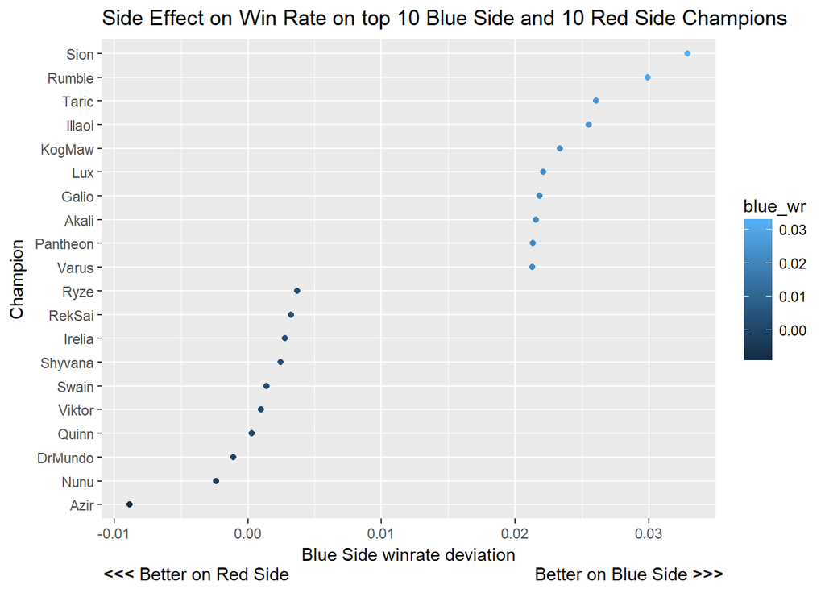

```r
# Get blue side winrates for each champion
blue_df <- winrate_df %>%
  filter(team == "BLUE") %>%
  mutate(blue_wr = team_wr - champ_wr)

# Get top 10 blue side winrates
high_df <- blue_df %>%
  arrange(desc(blue_wr)) %>%
  slice(1:10)

# Get bottom 10 blue side winrates
low_df <- blue_df %>%
  arrange(blue_wr) %>%
  slice(1:10)

# Combine the two data sets
blue_df <- rbind(low_df, high_df)

# Give levels to the factor so that the graph orders the champions based off of winrate
blue_df$champion <- factor(blue_df$champion, levels = blue_df$champion[order(blue_df$blue_wr)])

# Plot the champions by their winrates
blue_df %>%
  ggplot(aes(y = champion,
             x = blue_wr,
             color = blue_wr)) +
    geom_point() +
    labs(x="Blue Side winrate deviation
  <<< Better on Red Side                                                  Better on Blue Side >>>",
         y="Champion",
         title="Side Effect on Win Rate on top 10 Blue Side and 10 Red Side Champions")
```

### Calculate champion matchup winrates

Now I will calculate the third winrate, which is matchup-dependent. I want to find the champion that each person is facing, determined by the position they are in. I also want to make sure it’s a common matchup, not something that happened one rare time when a player picked someone at random, which could skew the data.

```r
matchup_df <- participants %>%
  inner_join(stats, by = "id") %>%
  mutate(role = 0)

# Give a role number for each position for more efficient filtering
matchup_df$role[matchup_df$position == "TOP"] <- 1
matchup_df$role[matchup_df$position == "JUNGLE"] <- 2
matchup_df$role[matchup_df$position == "MID"] <- 3
matchup_df$role[matchup_df$position == "CARRY"] <- 4
matchup_df$role[matchup_df$position == "SUPPORT"] <- 5

matchup_df <- matchup_df %>%
  # Only use teams with data properly recorded: one of each role on a team
  group_by(matchid, team) %>%
  filter(n_distinct(role) == 5) %>%
  # Only use matches where both teams are valid
  group_by(matchid) %>%
  filter(n() == 10) %>%
  # Get the lane matchup for each champion
  group_by(matchid, position) %>%
  mutate(matchup_lag = lag(champion),
         matchup_lead = lead(champion),
         matchup = "")

# Combine matchup into one column
matchup_df$matchup <- matchup_df$matchup_lag
matchup_df$matchup[!is.na(matchup_df$matchup_lead)] = matchup_df$matchup_lead[!is.na(matchup_df$matchup_lead)]

matchup_df <- matchup_df %>%
  select(-matchup_lag, -matchup_lead) %>%
  # Don't include super rare matchups
  group_by(champion, matchup) %>%
  filter(n() > 25) %>%
  mutate(matchup_wr = mean(win)) %>%
  ungroup()

matchup_df %>%
  select(champion, matchup, position, matchup_wr) %>%
  get_kable()
```

| champion | matchup | position | matchup_wr |
| --- | --- | --- | --- |
| Taliyah | Fizz | MID | 0.4000000 |
| Tryndamere | Riven | TOP | 0.4987147 |
| Teemo | Aatrox | TOP | 0.5694444 |
| Rakan | Thresh | SUPPORT | 0.4730145 |
| Ezreal | Draven | CARRY | 0.4486081 |

### Find winrate differences using three different methods

I want to now find the differences between each team and their opponent for all three methods of winrate. From there I can graph each method and find which ones are meaningful.

```r
wr_df <- winrate_df %>%
  # Join winrate stats to player stats
  inner_join(matchup_df, by = c("team", "champion")) %>%
  # Calculate average winrates for each team
  group_by(matchid, team, win) %>%
  summarize(champ_wr = mean(champ_wr), # Winrate based off of overall champion winrate
            team_wr = mean(team_wr), # Winrate based off of what team the champ is playing on
            match_wr = mean(matchup_wr)) %>% # Winrate based off of team matchups
  # Get the winrate stats for each team's opponent
  group_by(matchid) %>%
  mutate(team_lag = lag(team_wr),
         team_lead = lead(team_wr),
         champ_lag = lag(champ_wr),
         champ_lead = lead(champ_wr),
         match_lag = lag(match_wr),
         match_lead = lead(match_wr),
         enemy_wr = NA,
         enemy_cwr = NA,
         enemy_mwr = NA) %>%
  ungroup()

# Combine regular enemy winrate into one column
wr_df$enemy_wr <- wr_df$team_lag
wr_df$enemy_wr[!is.na(wr_df$team_lead)] = wr_df$team_lead[!is.na(wr_df$team_lead)]

# Combine scaled enemy winrate into one column
wr_df$enemy_cwr <- wr_df$champ_lag
wr_df$enemy_cwr[!is.na(wr_df$champ_lead)] = wr_df$champ_lead[!is.na(wr_df$champ_lead)]

# Combine matchup enemy winrate into one column
wr_df$enemy_mwr <- wr_df$match_lag
wr_df$enemy_mwr[!is.na(wr_df$match_lead)] = wr_df$match_lead[!is.na(wr_df$match_lead)]

wr_df <- wr_df %>%
  # Calculate winrate differences between each team and their opponent
  mutate(t_wr_diff = team_wr - enemy_wr,
         c_wr_diff = champ_wr - enemy_cwr,
         m_wr_diff = match_wr - enemy_mwr) %>%
  select(matchid, win, c_wr_diff, t_wr_diff, m_wr_diff) %>%
  na.omit()

get_kable(wr_df)
```

| matchid | win | c_wr_diff | t_wr_diff | m_wr_diff |
| --- | --- | --- | --- | --- |
| 128139 | FALSE | 0.0030043 | 0.0287631 | 0.0441753 |
| 47062 | TRUE | -0.0199701 | 0.0092465 | -0.0453037 |
| 77237 | FALSE | -0.0112640 | -0.0315622 | -0.0802685 |
| 4125 | FALSE | -0.0009460 | -0.0306306 | -0.0160473 |
| 29279 | TRUE | 0.0051517 | -0.0223571 | 0.0543719 |

### Comparing the winrate methods

I need to graph a team’s actual winrate based off of the three winrate attributes I just found.

#### Champion Winrate

There is a clear correlation between having a higher champion winrate and having a higher team winrate.

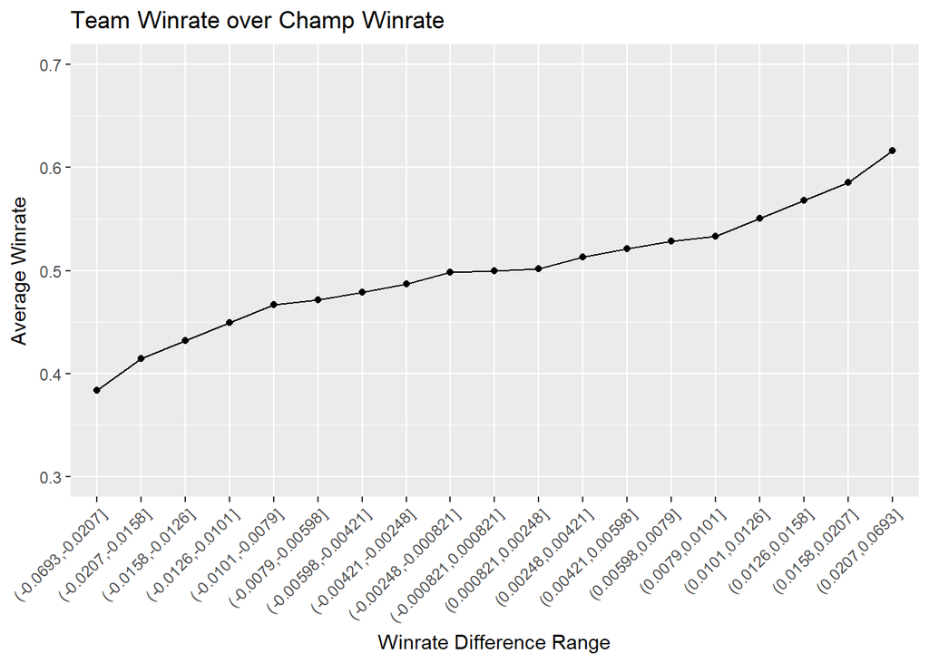

```r
wr_df %>%
  # Divide champ winrate into 20 buckets, scaled to each have the same size
  mutate(c_range = cut(c_wr_diff, breaks=quantile(c_wr_diff, probs=seq(0,1,len=20)))) %>%
  na.omit() %>%
  # Get the winrate for each overall winrate range
  group_by(c_range) %>%
  mutate(c_wr = mean(win)) %>%
  # Graph each winrate range to compare which one has better correlation
  ggplot(aes(x = c_range, y = c_wr, group = 1)) +
    geom_point() +
    geom_line() +
    theme(axis.text.x = element_text(angle = 45, vjust = 1, hjust = 1)) +
    labs(x="Winrate Difference Range",
         y="Average Winrate",
         title="Team Winrate over Champ Winrate") +
    ylim(0.3, 0.7)
```

#### Side Winrate

Adjusting winrate for the side does not actually improve the data set but instead skews it. It looks like side-based winrate does not matter as much.

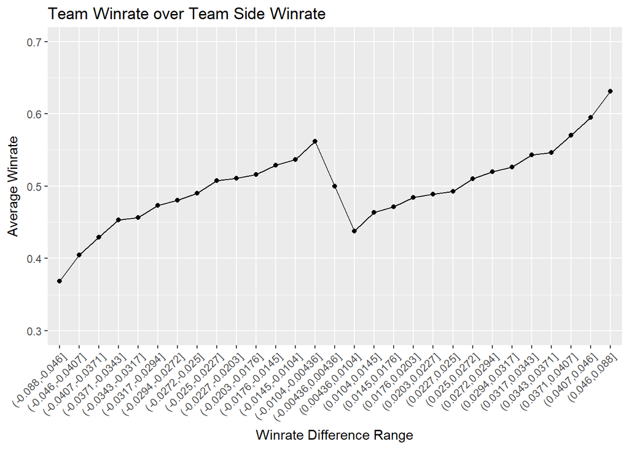

```r
wr_df %>%
  # Divide team winrate into 20 buckets, scaled to each have the same size
  mutate(t_range = cut(t_wr_diff, breaks=quantile(t_wr_diff, probs=seq(0,1,len=30)))) %>%
  na.omit() %>%
  # Get the winrate for each overall winrate range
  group_by(t_range) %>%
  mutate(t_wr = mean(win)) %>%
  # Graph each winrate range to compare which one has better correlation
  ggplot(aes(x = t_range, y = t_wr, group = 1)) +
    geom_point() +
    geom_line() +
    theme(axis.text.x = element_text(angle = 45, vjust = 1, hjust = 1)) +
    labs(x="Winrate Difference Range",
         y="Average Winrate",
         title="Team Winrate over Team Side Winrate") +
    ylim(0.3, 0.7)
```

#### Matchup Winrate

Matchup winrate has an even better correlation than champion winrate. Picking better matchups is as important or more important than picking high winrate champions.

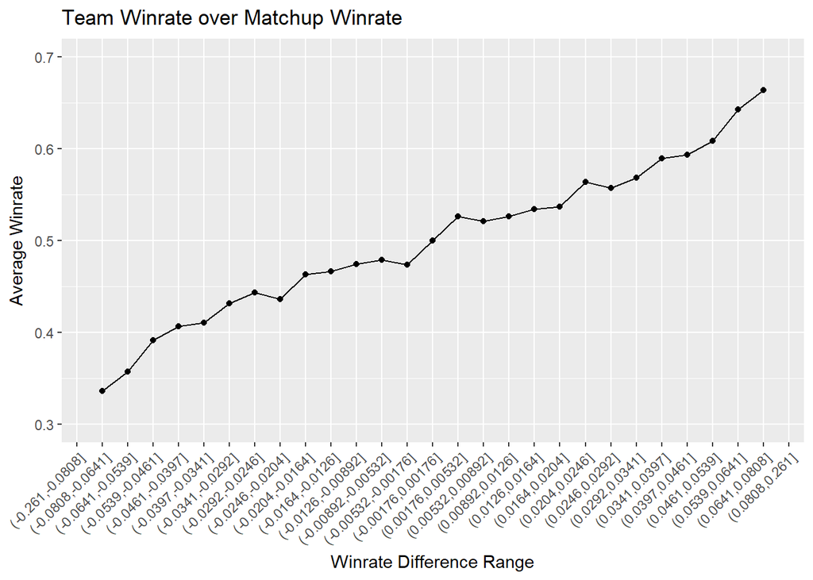

```r
wr_df %>%
  # Divide winrate difference into 30 buckets, scaled to each have the same size
  mutate(range = cut(m_wr_diff, breaks=quantile(m_wr_diff, probs=seq(0,1,len=30)))) %>%
  na.omit() %>%
  # Get the winrate for each overall winrate range
  group_by(range) %>%
  mutate(wr = mean(win)) %>%
  # Graph each winrate range to compare which one has better correlation
  ggplot(aes(x = range, y = wr, group = 1)) +
    geom_point() +
    geom_line() +
    theme(axis.text.x = element_text(angle = 45, vjust = 1, hjust = 1)) +
    labs(x="Winrate Difference Range",
         y="Average Winrate",
         title="Team Winrate over Matchup Winrate") +
    ylim(0.3, 0.7)
```

## Damage ratios

Another stat I’m interested in is damage ratios. In League, damage can be physical, magic, or true damage. Each one can be protected against by armor, magic resist, and health, respectively. If all your champions do magic damage, the enemy can just build magic resist to counter it. It’s widely believed that balancing the types of damage you do is best.

### Calculate average damage ratios for all champions

I need to calculate the damage ratios for all champions. I’m interested in the physical to magic damage ratio, as those are the two main types of damage. I’m also interested to see if true damage plays a factor, so I want find the true to other damage ratio.

```r
avg_dmg <- participants %>%
  select(id, player, champion, common_role) %>%
  left_join(stats, by = "id") %>%
  na.omit() %>%
  # Get average damage dealt in each category for each champion
  group_by(champion) %>%
  summarize(avg_magic_dealt = mean(magicdmgtochamp),
         avg_phys_dealt = mean(physdmgtochamp),
         avg_true_dealt = mean(truedmgtochamp)) %>%
  # Get damage ratios for each champion
  mutate(physmagic_dealt_ratio = avg_phys_dealt / avg_magic_dealt,
         true_dealt_ratio = avg_true_dealt / (avg_phys_dealt + avg_magic_dealt)) %>%
  select(champion, physmagic_dealt_ratio, true_dealt_ratio)

get_kable(avg_dmg)
```

| champion | physmagic_dealt_ratio | true_dealt_ratio |
| --- | --- | --- |
| Kalista | 17.064443 | 0.0259117 |
| Caitlyn | 20.351447 | 0.0270062 |
| Udyr | 4.512349 | 0.1106239 |
| Sejuani | 1.030878 | 0.0803640 |
| Urgot | 16.182002 | 0.0151052 |

### Test if true damage is independent of other damage types

If true damage is more prevalent on AP champs, then I may need to consider manipulating the data. I want to find the most true damage champs and compare that to their phys:magic ratio. Because there isn’t a pattern between high true damage, high phys/magic damage, and role, I may not need to consider true damage in my analysis.

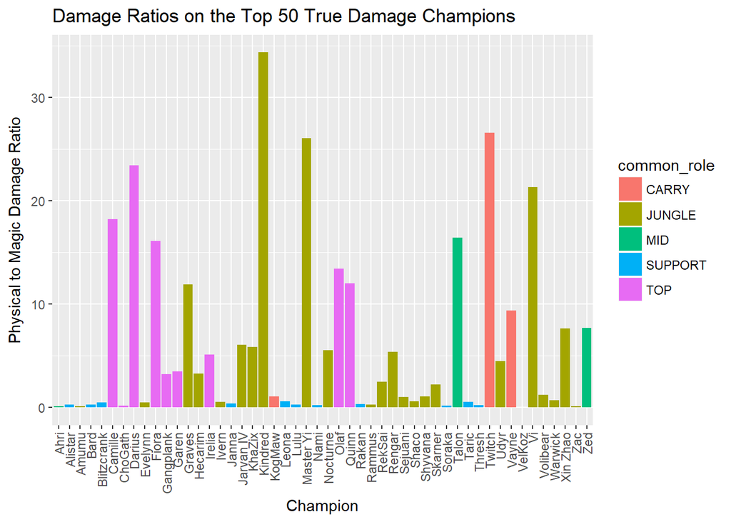

```r
true_dmg <- avg_dmg

# Order champions by their true damage ratio
true_dmg$champion <- factor(avg_dmg$champion, levels = avg_dmg$champion[order(avg_dmg$true_dealt_ratio)])

true_dmg %>%
  # Get the top 50 true damage champs
  arrange(desc(true_dealt_ratio)) %>%
  left_join(champ_roles, by = "champion") %>%
  slice(1:50) %>%
  # Graph the true damage champs based on their physical to magic damage ratio
  ggplot(aes(x = champion, y = physmagic_dealt_ratio, fill = common_role)) +
    geom_col() +
    theme(axis.text.x = element_text(angle = 90, vjust = 0.5, hjust = 1)) +
    labs(x = "Champion",
         y = "Physical to Magic Damage Ratio",
         title = "Damage Ratios on the Top 50 True Damage Champions")
```

### Visualize damage ratio over winrate and find optimal ratio

My next question is: is there an *optimal* damage ratio number? If so, what is it? I want to graph winrates based on this ratio and use a line of best fit to find an optimal number.

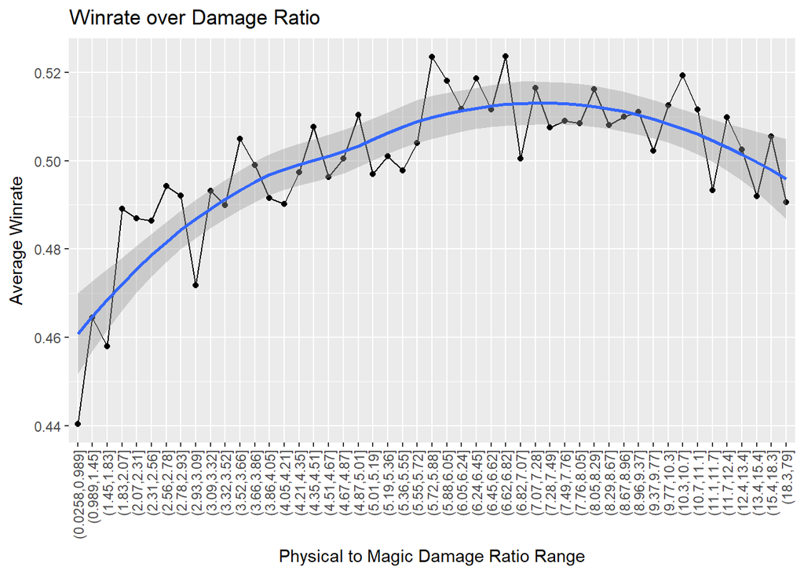

```r
ratio_df <- participants %>%
  # Join with stats to get win
  inner_join(stats, by = "id") %>%
  # Join to get each champion's average damage
  left_join(avg_dmg, by = "champion") %>%
  # Get each team's average physical to magic damage ratio and whether they won
  group_by(matchid, team, win) %>%
  summarize(physmagic_ratio = mean(physmagic_dealt_ratio)) %>%
  ungroup()

ratio_df %>%
  # Divide the ratio into 50 evenly sized ranges
  mutate(ratio_range = cut(physmagic_ratio, breaks=quantile(physmagic_ratio, probs=seq(0,1,len=50)))) %>%
  # Get the winrate for each range
  group_by(ratio_range) %>%
  summarize(wr = mean(win)) %>%
  na.omit() %>%
  # Graph the winrate of each range to find optimal ratio
  ggplot(aes(x = ratio_range,
             y = wr,
             group = 1)) +
    geom_point() +
    geom_line() +
    geom_smooth(method = 'loess') +
    theme(axis.text.x = element_text(angle = 90,
                                     vjust = 0.5,
                                     hjust = 1)) +
      labs(x = "Physical to Magic Damage Ratio Range",
           y = "Average Winrate",
           title = "Winrate over Damage Ratio")
```

### Test correlation between deviation from optimal and winrate

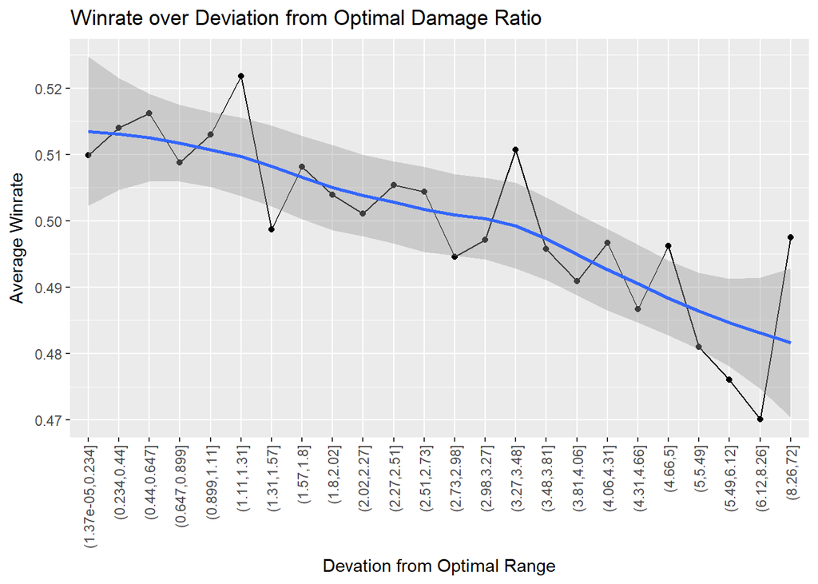

```r
ratio_df <-ratio_df %>%
  # Store optimal ratio
  mutate(optimal = 7) %>%
  # Find distance from optimal ratio
  mutate(physmagic_diff = abs(physmagic_ratio - optimal))

ratio_df %>%
  # Divide the difference into 25 equally sized ranges
  mutate(diff_range = cut(physmagic_diff, breaks=quantile(physmagic_diff, probs=seq(0,1,len=25)))) %>%
  # Get the winrate for each range
  group_by(diff_range) %>%
  summarize(wr = mean(win)) %>%
  na.omit() %>%
  # Graph winrate by how far a team is from the optimal damage ratio
  ggplot(aes(x = diff_range,
             y = wr,
             group = 1)) +
    geom_point() +
    geom_line() +
    geom_smooth(method = "loess") +
    theme(axis.text.x = element_text(angle = 90,
                                     vjust = 0.5,
                                     hjust = 1)) +
    labs(x = "Devation from Optimal Range",
         y = "Average Winrate",
         title = "Winrate over Deviation from Optimal Damage Ratio")
```

## Role Banned

One of the last stats I can determine from the start of the game is what champions were banned. I want to determine which bans are best, but there are too many champions to do that at the moment. Instead, I’ll generalize by the role of the champion that was banned.

### Calculate roles banned for each team

I first need to get the percentage of bans used on each role for each team

```r
avg_bans <- teambans %>%
  # Extrapolate team color from teamid
  mutate(team = ifelse(teamid == 100, "BLUE", "RED")) %>%
  # Tidy bans giving each their own column
  mutate(is_top = (common_role=="TOP")) %>%
  mutate(is_jungle = (common_role=="JUNGLE")) %>%
  mutate(is_mid = (common_role=="MID")) %>%
  mutate(is_carry = (common_role=="CARRY")) %>%
  mutate(is_support = (common_role=="SUPPORT")) %>%
  # Get percentage of bans used on each role for each match
  group_by(matchid, team) %>%
  summarize(pct_top = mean(is_top),
            pct_jungle = mean(is_jungle),
            pct_mid = mean(is_mid),
            pct_carry = mean(is_carry),
            pct_support = mean(is_support)) %>%
  filter(pct_top != .50 &
         pct_jungle != .50 &
         pct_mid != .50 &
         pct_carry != .50 &
         pct_support != .50) %>%
  ungroup()

avg_bans <- stats %>%
  left_join(participants, by = "id") %>%
  group_by(matchid, team, win) %>%
  summarize() %>%
  ungroup() %>%
  inner_join(avg_bans, by = c("matchid", "team"))

get_kable(avg_bans)
```

| matchid | team | win | pct_top | pct_jungle | pct_mid | pct_carry | pct_support |
| --- | --- | --- | --- | --- | --- | --- | --- |
| 2138 | BLUE | TRUE | 0.0000000 | 0.6666667 | 0.0000000 | 0.3333333 | 0.0000000 |
| 136545 | RED | TRUE | 0.0000000 | 0.0000000 | 0.3333333 | 0.3333333 | 0.3333333 |
| 119565 | RED | FALSE | 0.3333333 | 0.3333333 | 0.3333333 | 0.0000000 | 0.0000000 |
| 54740 | BLUE | TRUE | 0.0000000 | 0.3333333 | 0.3333333 | 0.0000000 | 0.3333333 |
| 22852 | BLUE | TRUE | 0.0000000 | 0.0000000 | 0.6666667 | 0.0000000 | 0.3333333 |

### Visualize how roles banned have changed over time

I want to see if specific roles get banned more than others, and also how that’s changed over time. If there is a clear leader in ban percentages, it may signal that banning that role is more important to winrate.

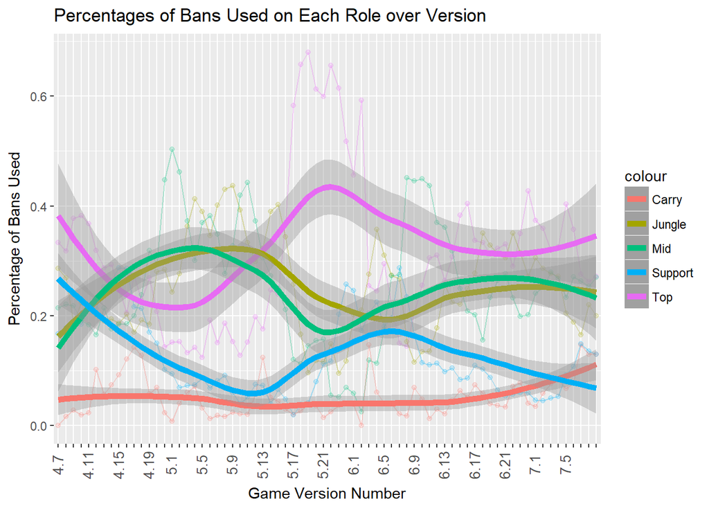

```r
# Store aesthetic variables for each of the positions
top_aes <- aes(y = ban_top, color = "Top")
jungle_aes <- aes(y = ban_jungle, color = "Jungle")
mid_aes <- aes(y = ban_mid, color = "Mid")
carry_aes <- aes(y = ban_carry, color = "Carry")
support_aes <- aes(y = ban_support, color = "Support")

# Quick functions to get specific plot settings
Smooth <- function(ae) {
  geom_smooth(ae, method='loess', size = 2)
}
Point <- function(ae) {
  geom_point(ae, alpha = 0.2)
}
Line <- function(ae) {
  geom_line(ae, alpha = 0.3)
}

matches %>%
  inner_join(avg_bans, by="matchid") %>%
  # Get average bans used on each role for each version
  group_by(ver) %>%
  summarize(ban_top = mean(pct_top),
            ban_jungle = mean(pct_jungle),
            ban_mid = mean(pct_mid),
            ban_carry = mean(pct_carry),
            ban_support = mean(pct_support)) %>%
  # Graph bans on each role by version
  ggplot(aes(factor(ver),
             group = 1)) +
    # Add points for each role
    Point(top_aes) + Point(jungle_aes) + Point(mid_aes) + Point(carry_aes) + Point(support_aes) +
    # Add a line between points
    Line(top_aes) + Line(jungle_aes) + Line(mid_aes) + Line(carry_aes) + Line(support_aes) +
    # Add a line of best fit for each role
    Smooth(top_aes) + Smooth(jungle_aes) + Smooth(mid_aes) + Smooth(carry_aes) + Smooth(support_aes) +
    theme(axis.text.x = element_text(angle = 90,
                                     vjust = 0.4,
                                     size=10)) +
    labs(x = "Game Version Number",
         y = "Percentage of Bans Used",
         title = "Percentages of Bans Used on Each Role over Version") +
    scale_x_discrete(labels=ver_labels)
```

### Test for optimal role ban rate

I want to also check how winrate is affected by the role a team bans. I need to graph each role ban and it’s corresponding winrate. Overall, the graph doesn’t show any significant pattern, so the role banned by a team probably isn’t useful data.

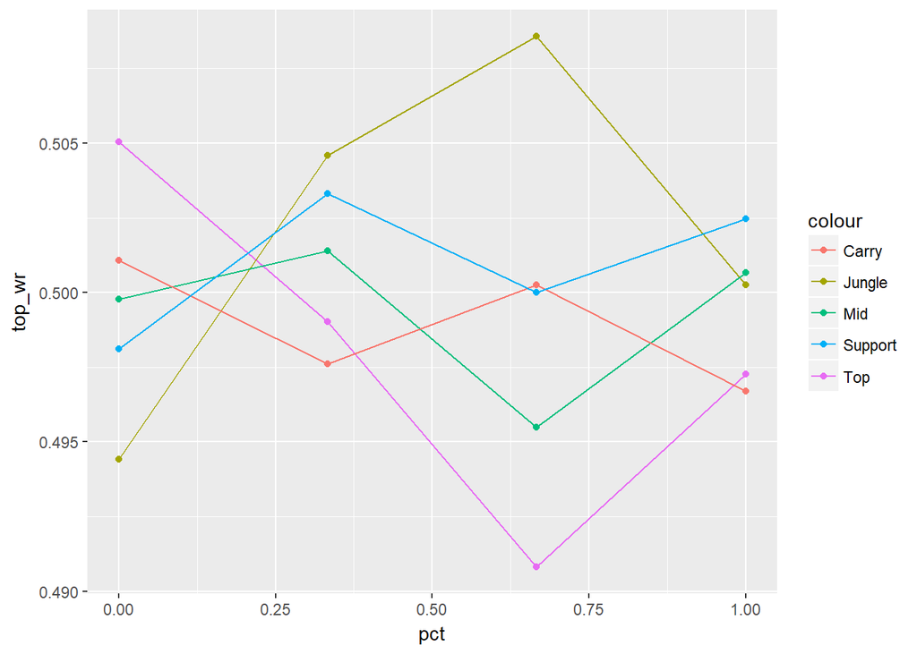

```r
top_bans <- avg_bans %>%
  # Get top ban winrates
  group_by(pct_top) %>%
  summarize(top_wr = mean(win)) %>%
  rename(pct = pct_top)

jungle_bans <- avg_bans %>%
  # Get jungle ban winrates
  group_by(pct_jungle) %>%
  summarize(jungle_wr = mean(win)) %>%
  rename(pct = pct_jungle)

mid_bans <- avg_bans %>%
  # Get mid ban winrates
  group_by(pct_mid) %>%
  summarize(mid_wr = mean(win)) %>%
  rename(pct = pct_mid)

carry_bans <- avg_bans %>%
  # Get carry ban winrates
  group_by(pct_carry) %>%
  summarize(carry_wr = mean(win)) %>%
  rename(pct = pct_carry)

support_bans <- avg_bans %>%
  # Get support ban winrates
  group_by(pct_support) %>%
  summarize(support_wr = mean(win)) %>%
  rename(pct = pct_support)

top_bans %>%
  # Join all the ban winrates together
  left_join(jungle_bans, by = "pct") %>%
  left_join(mid_bans, by = "pct") %>%
  left_join(carry_bans, by = "pct") %>%
  left_join(support_bans, by = "pct") %>%
  # Graph winrates for each ban level
  ggplot(aes(x = pct)) +
    geom_point(aes(y= top_wr, color = "Top")) +
    geom_point(aes(y= jungle_wr, color = "Jungle")) +
    geom_point(aes(y= mid_wr, color = "Mid")) +
    geom_point(aes(y= carry_wr, color = "Carry")) +
    geom_point(aes(y= support_wr, color = "Support")) +
    geom_line(aes(y= top_wr, color = "Top")) +
    geom_line(aes(y= jungle_wr, color = "Jungle")) +
    geom_line(aes(y= mid_wr, color = "Mid")) +
    geom_line(aes(y= carry_wr, color = "Carry")) +
    geom_line(aes(y= support_wr, color = "Support"))
```

# Predictive Model

I’ve determined that a team’s CS/Min rate, champion winrate, matchup winrate, and damage ratios all can correlate with that team’s winrate. I now should have enough data to build a model predicting winrate.

### Assemble relevant data

I need to combine all the values I calculated before into a single data set I can use.

```r
# Join together necessary data frames
team_df <- ratio_df %>%
  left_join(wr_df, by = c("matchid", "win")) %>%
  left_join(team_cs_df, by = c("matchid", "win", "team")) %>%
  na.omit() %>%
  # Select necessary attributes
  select(win, physmagic_diff, c_wr_diff, m_wr_diff, cs_diff)

get_kable(team_df)
```

| win | physmagic_diff | c_wr_diff | m_wr_diff | cs_diff |
| --- | --- | --- | --- | --- |
| TRUE | 4.5164650 | 0.0051244 | 0.0728521 | -0.5917592 |
| FALSE | 0.8671294 | -0.0084522 | -0.0449702 | 0.2425214 |
| TRUE | 0.7867828 | -0.0305962 | 0.0285424 | -0.0571940 |
| FALSE | 4.0218530 | -0.0068200 | -0.0101098 | 0.0212185 |
| FALSE | 3.6915098 | -0.0041668 | -0.0902799 | 0.1707159 |

### Predict game winners pre-game and visualize error rates

I want to create a classification prediction model to determine game winner. I’m also using cross-validation to determine the error rate, and how often the model can predict a game winner.

After the model is trained and tested, the error rate comes out to about 42% on the model. That means that I’m only 8% better than a coin flip even after all the data I extrapolated. While that number may seem small, the game is made to be as close to a coin flip as possible, and a 8% increase over that is very valuable to players who are looking for any advantage they can.

There are also other ways I could have improved my model that weren’t possible due to the data set. I could also take into account each player’s past performance overall, or more specifically on the character and role they are playing. I also could have gone more in depth with the data I've got and looked at the winrates of the champions banned.

```r
team_data <- team_df %>%
  na.omit()

# Divide data set into 10 folds
fold_indices <- cvFolds(n=nrow(team_df), K = 10)

error_rates <- sapply(1:10, function(fold_index) {
  test_indices <- which(fold_indices$which == fold_index)
  # Get test and training set
  test_set <- team_df[test_indices,]
  train_set <- team_df[-test_indices,]

  # Fit the logistic regression model
  logis_fit <-  glm(win~., data = train_set, family = "binomial")
  logis_pred <- ifelse(predict(logis_fit, newdata = test_set, type = "response") > 0.5, 1, 0)
  logis_error <- mean(test_set$win != logis_pred)

  logis_error
})

avg_error_rates <- as.data.frame(t(error_rates)) %>%
  mutate(fold=1:n()) %>%
  gather(method,error,-fold) %>%
  # Get the average error rate
  summarize(error = mean(error))

kable(avg_error_rates) %>%
  kable_styling(bootstrap_options = c("striped", "hover", "condensed", "responsive"))
```

| error |
| --- |
| 0.4208306 |

# Build easier prediction model using end-of-match data

With the slightly discouraging result of my pre-game prediction model, I want to make sure I’m able to improve my results if I use data collected after a match finished.

### Assemble match data

The end-of-match stats are very cleanly collected, so I am easily able to determine important average values for each team that could be used in another prediction model

```r
full_team_df <- teamstats %>%
  inner_join(participants, by = c("matchid", "team"))  %>%
  inner_join(select(stats, -firstblood), by = "id")

# Treat entities with 0 deaths as 1 for the purpose of KDA calculations
full_team_df$deaths[full_team_df$deaths == 0] = 1

full_team_df <- full_team_df %>%
  group_by(matchid, team, win) %>%
  # Assemble relevant match statistics
  summarize(firstblood = first(firstblood),
            firsttower = first(firsttower),
            firstinhib = first(firstinhib),
            firstharry = first(firstharry),
            towerkills = first(towerkills),
            baronkills = first(baronkills),
            dragonkills = first(dragonkills),
            kda = (mean(kills) + mean(assists)) / mean(deaths),
            damage = mean(totdmgtochamp),
            visionscore = mean(visionscore),
            goldearned = mean(goldearned),
            turretdmg = sum(dmgtoturrets),
            cs_min = sum(totminionskilled) / (first(duration)/60)) %>%
  ungroup() %>%
  na.omit() %>%
  select(-team, -matchid)

get_kable(full_team_df)
```

| win | firstblood | firsttower | firstinhib | firstharry | towerkills | baronkills | dragonkills | kda | damage | visionscore | goldearned | turretdmg | cs_min |
| --- | --- | --- | --- | --- | --- | --- | --- | --- | --- | --- | --- | --- | --- |
| TRUE | 1 | 0 | 1 | 0 | 9 | 1 | 3 | 3.9230769 | 24103.4 | 32.4 | 15186.8 | 24597 | 19.82379 |
| FALSE | 0 | 0 | 0 | 0 | 1 | 0 | 1 | 0.8461538 | 8815.8 | 0.0 | 7484.6 | 0 | 22.56478 |
| FALSE | 0 | 0 | 0 | 0 | 1 | 0 | 1 | 1.3823529 | 14686.2 | 0.0 | 9399.6 | 1457 | 17.73349 |
| TRUE | 1 | 1 | 1 | 1 | 10 | 1 | 1 | 3.1052632 | 12511.2 | 12.8 | 10531.2 | 39249 | 23.69535 |
| FALSE | 0 | 0 | 0 | 0 | 5 | 0 | 2 | 1.6428571 | 19084.2 | 29.6 | 12117.6 | 11139 | 19.10504 |

### Predict game winners post-game and visualize error rates

Using the new stats I got from after the game ended, my model improved to a 3% error rate. This is much more re-assuring, but a much more useless prediction model.

```r
full_set <- full_team_df %>%
  na.omit()

# Divide data set into 10 folds
fold_indices <- cvFolds(n=nrow(full_set), K = 10)

error_rates <- sapply(1:10, function(fold_index) {
  test_indices <- which(fold_indices$which == fold_index)
  # Get test and training set
  test_set <- full_set[test_indices,]
  train_set <- full_set[-test_indices,]

  # Fit the logistic regression model
  logis_fit <-  glm(win~., data = train_set, family = "binomial")
  logis_pred <- ifelse(predict(logis_fit, newdata = test_set, type = "response") > 0.5, TRUE, FALSE)
  logis_error <- mean(test_set$win != logis_pred)

  logis_error
})

avg_error_rates <- as.data.frame(t(error_rates)) %>%
  mutate(fold=1:n()) %>%
  gather(method,error,-fold) %>%
  # Get average error rate
  summarize(error = mean(error))

kable(avg_error_rates) %>%
  kable_styling(bootstrap_options = c("striped", "hover", "condensed", "responsive"))
```

| error |
| --- |
| 0.0313586 |

# Conclusion

By limiting myself to only looking at pre-game statistics, I created a model that was only marginally better than a coin flip. However, this result was better than expected. First, considering the efforts the developers have made to make the game as even as possible, anything significantly different than 50% is an improvement and a useful model. Additionally, the game is built to be primarily decided by each individual player’s performance during the game rather than what they pick before the game starts.

With more extensive analysis I could expand my initial model and possibly improve the accuracy, but the data set is limited. I answered a lot of questions I had about the game, and this process has made me even more excited to potentially expand this to more games that I love, such as CS:GO, PUBG, or Rocket League.

# Further Reading

[Tidyverse](https://www.tidyverse.org/)

[Predictive Modelling](https://en.wikipedia.org/wiki/Predictive_modelling)

[League of Legends](https://na.leagueoflegends.com/en/)